# Lab 4 – Visualizing Model Assumptions

Your Group Names Here (include last names!)

Due: September 24 by 5pm

For this lab we will look at the rate of deaths by age/gender (per 100,000 population) for people killed in crashes involving a driver with BAC =>0.08%. These data come from the CDC (Center for Disease Control and Prevention) for the years 2012 and 2014.

Data for 2012 and 2014 were obtained from the National Highway Traffic Administration’s (NHTSA) Fatality Analysis Reporting System (FARS). Blank cells indicate data are suppressed. Fatality rates based on fewer than 20 deaths are suppressed.

# Modeling Differences in Fatalities between 2012 and 2014

We could investigate if the rate of deaths (per 100,000 people) from drunk driving has changed between 2012 and 2014.

```r
drunk_all_years <- drunk %>%
  # selecing only the two columns with data on all deaths for 2012 & 2014
  select(`All Ages, 2012`, `All Ages, 2014`) %>%
  # gathering the two columns into one column called year and another called deaths
  gather(`All Ages, 2012`:`All Ages, 2014`, key = "year", value = "deaths") %>%
  # changing the year column to be only 2012 and 2014 (removing the All Ages prefix)
  mutate(year = case_when(year == "All Ages, 2012" ~ "2012",
                          year == "All Ages, 2014" ~ "2014")) %>%
  # filtering out any years with NA values for fatalities
  filter(is.na(deaths) == FALSE)
```

Alright, to investigate the differences in the fatality rates in 2012 versus 2014, we could conduct a permutation test or a t-test.

**1. What are the assumptions of a permutation test?**

**2. What assumption does a t-test have that a permutation test does not?**

## Visualizing Model Assumptions

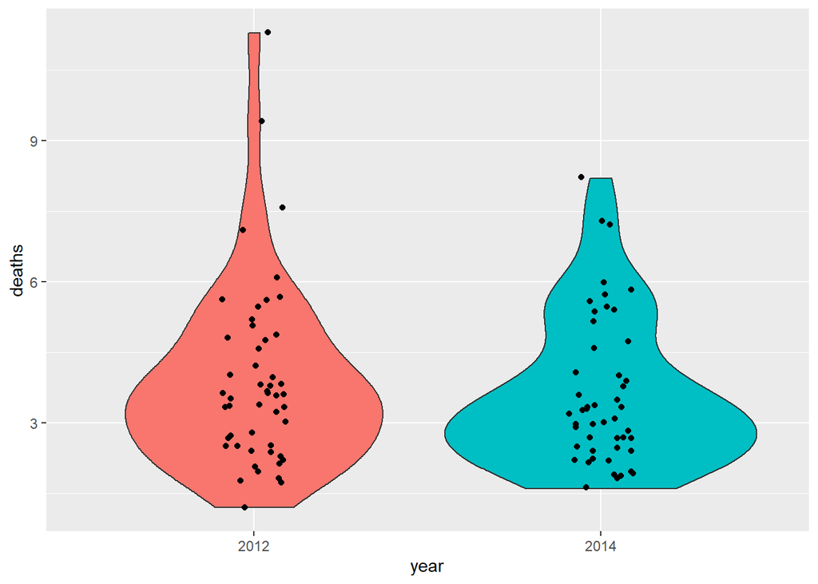

```r
drunk_all_years %>%
  # pipe dataset into the plot
  ggplot(aes(x = year, y = deaths)) +
  # specify x and y variables
  geom_violin(aes(fill = year)) +
  # specify how the violins should be colored
  geom_jitter(width = 0.1) +
  # adds data points on top of the violins
  theme(legend.position = "none")  # removes legend from plot, since it is redundant with x-axis label
```

**3. What assumption(s) does this plot help you assess? What information do you see in the plot that is not included in the table of standard deviations below?**

```r
drunk_all_years %>%
  group_by(year) %>%
  summarize(sd = sd(deaths))
```

```
## # A tibble: 2 x 2
##   year     sd
##   <chr> <dbl>
## 1 2012   1.95
## 2 2014   1.58
```

The assumption of normally distributed residuals (or the responses) can be kind of tricky to figure out! Let’s look at a plot of the residuals from the model fit to these data. To obtain the residuals from the data model, we need to carry out the following steps:

1. Fit a model using `lm`, with a quantitative response and a categorical explanatory
2. Pull off the residuals from the model and store in a new variable in the dataset

Once we’ve done these steps, we can create a density plot or histogram of the model’s residuals. Using this plot, we can assess the assumption of normality of residuals!

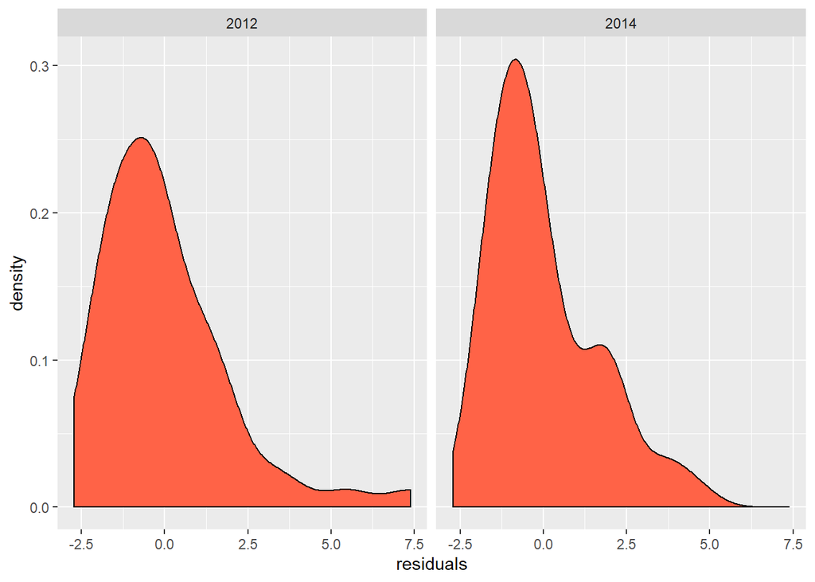

```r
# Fit a linear model to the data, with quant response and categor explanatory
drunk_lm <- lm(deaths ~ year, data = drunk_all_years)

drunk_all_years %>%
  # Create a new variable that's the residuals from the linear model
  mutate(residuals = residuals(drunk_lm)) %>%
  # Plot a density plot of the residuals
  ggplot(aes(x = residuals)) +
  # Choose your color!
  geom_density(fill = "tomato") +
  # Separate density plots for each year
  facet_wrap(~ year)
```

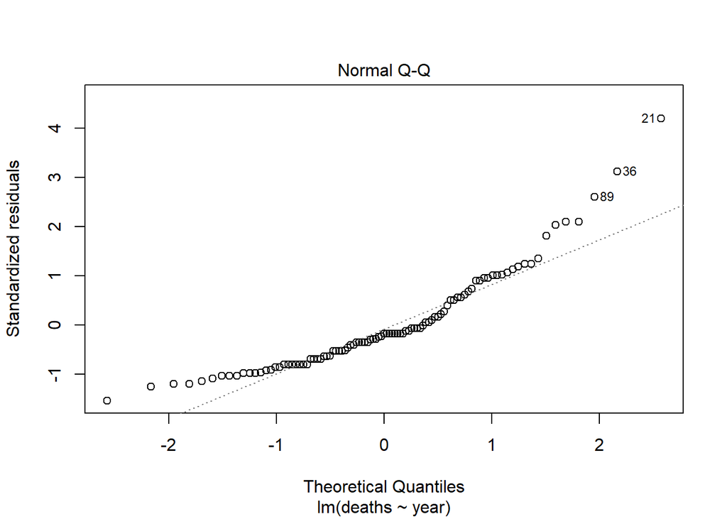

```r
# The standard base R plot for assessing normality of residuals
plot(drunk_lm, which = 2)
```

**4. Do you believe the assumption of normally distributed responses is violated? Why or why not?**

## Training Models

```r
library(infer)

# CONDUCTING A T-TEST

drunk_all_years %>%
  # t_test gives a tidier output than t.test
  t_test(deaths ~ year, # specify response ~ explanatory
         order = c("2014", "2012"),  # specify order of subtraction
         alternative = "two_sided",  # specify direction of alternative
         mu = 0, # specify mean in null hypothesis (if 2104 = 2012, then 2014 - 2012 = 0)
         conf_int = FALSE, # specify if you want a confidence interval (TRUE = yes, FALSE = no)
         conf_level = 0.99 #specify the confidence level to be used for the interval
  )
```

```
## # A tibble: 1 x 4
##   statistic  t_df p_value alternative
##       <dbl> <dbl>   <dbl> <chr>
## 1    -0.818  93.8   0.415 two.sided
```

```r
# CONDUCTING A PERMUATION TEST

# Step 1: Calculate observed difference in mean fatality
obs_diff <- drunk_all_years %>%
  specify(deaths ~ year) %>%
  calculate(stat = "t",
            order = c("2014", "2012")
            )

# Step 2: Generate permuted differences in mean fatality
permute <- drunk_all_years %>%
  specify(deaths ~ year) %>%
  hypothesize(null = "independence") %>%
  generate(reps = 5000, type = "permute") %>%
  calculate(stat = "t",
            order = c("2014", "2012")
            )

# Step 3: Calculate the p-value based on permuted differences in means
permute %>% # using the vector of permuted differences in means
  get_p_value(obs_stat = obs_diff, # declare the observed difference in means
              direction = "two_sided" # state the direction for the test
              )
```

```
## # A tibble: 1 x 1
##   p_value
##     <dbl>
## 1   0.416
```

**5. Do the results of the two tests differ? Why do you believe this is the case?**

# Your Turn: Modeling Differences in Fatalities Between Sexes

We could investigate if the rate of deaths (per 100,000 people) in 2014 for males and females differs. Now, instead of comparing across years, we are comparing across sexes within the *same* year.

## Gathering 2014 Data

First, we need to gather the two columns on Male and Female fatalities in 2014. Using the code above, write code to:

1. Select the `Male, 2014` and `Female, 2014` columns
2. Transform these columns from wide format to long format, specifying a new key that is relevant to the variables being gathered
3. Change the values of the variable you named (in the `key` argument of `gather`) to take on values of “Male” and “Female” instead

**6. Insert your code here!**

Next, we need to investigate what type of procedure we should use to test if there is a difference in fatality rates for males versus females. To do this, we need to create plots to determine how violate the model’s assumptions are.

**7. Create a side-by-side violin plot of the fatality rates for the two sexes.**

**8. Determine how violated each of the assumptions for conducting a t-test is.**

- **Independence:**
- **Normality of Errors/Response:**
- **Equal Variance:**